# Reproducible Research Peer Assessment 1

## Summary

This is the Reproducible Research Peer Assignment #1, which intends to answer a series of questions based on the data collected from personal activity monitoring device. The device collected at 5 minute intervals through out the day and consists of 2 months of data from anonymous individual collected during the months of October and November 2012. It includes the numer of steps taken in 5 minute intervals each day. The dataset activity.csv has the following variables:

1. Steps: Number of steps taking in a 5 minute interval (missing values are coded as NA)
2. date: The date on which teh measurement was taken in YYYY-MM-DD
3. interval: Identifier for the 5 minute interval in which measurement was taken.

## Loading and preprocessing the data

First download the data activity.zip and read the activity.csv file:

```r
if (!file.exists("activity.zip")){
 d <- "https://d396qusza40orc.cloudfront.net/repdata%2Fdata%2Factivity.zip"
 setInternet2(use=TRUE)
 download.file(url=d,destfile="activity.zip")
 unzip("activity.zip")
 unlink("activity.zip")

 activity <- read.csv("activity.csv")
}
```

The activity.csv file has 17568 observations.

## What is mean total number of steps taken per day

Here is the distribution of the steps taken per day from the dataset. Aggregate function here by default ignores the missing value.

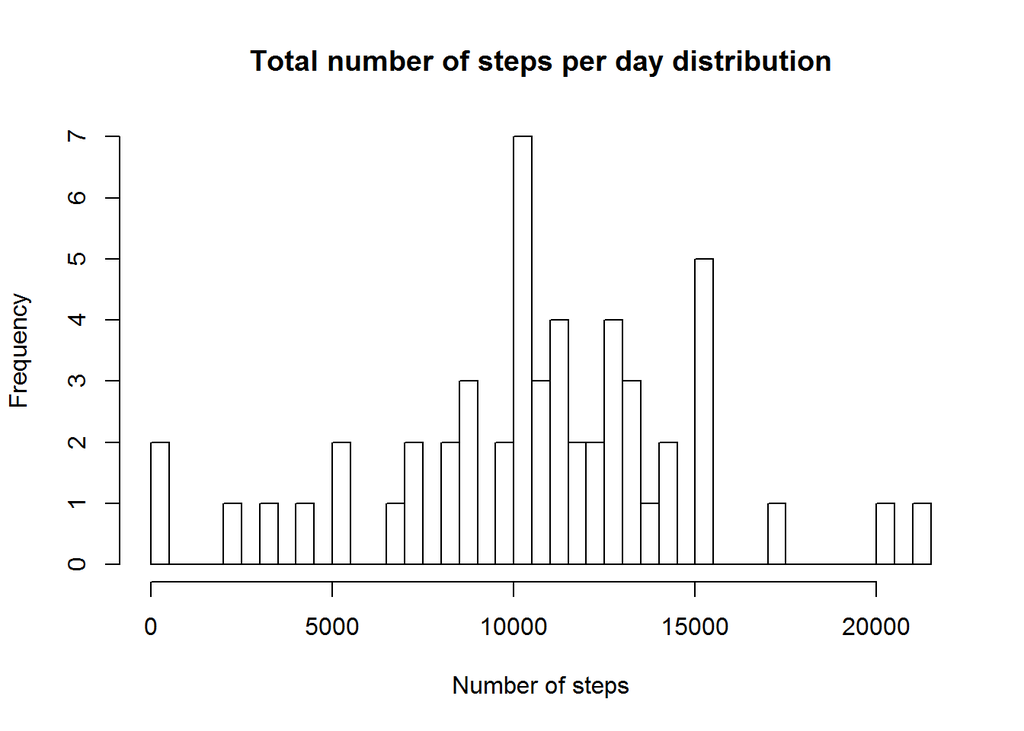

```r
options(scipen =1)
 c <-aggregate(steps ~ date, activity, sum)
 n <- dim(c)[1]
 hist( c$steps, xlab= "Number of steps", main="Total number of steps per day distribution",breaks=n)
```

```r
 step.mean <- mean(c$steps)
 step.median <-median(c$steps)
```

The mean of steps taken per day is 10766 and the median of steps taken per day is 10765

## What is the average daily activity pattern

Here we average each interval across all the days and plot the average steps against the interval.

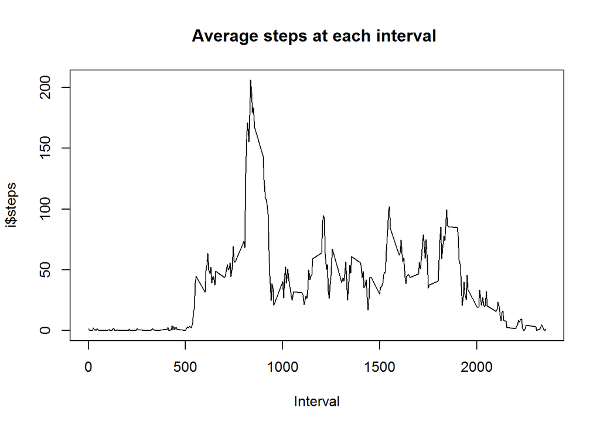

```r
 i <- aggregate(steps ~ interval, data=activity, mean)
 plot(i$interval,i$steps,type="l",xlab="Interval",main="Average steps at each interval ")
```

```r
 max <- i[i$steps == max(i$steps),1]
```

The interval which contains the maximum average number of steps is 835.

## Inputing missing values

```r
 j <- is.na(activity$steps)
 missing.values <- sum(j)
```

Total number of 2304 has missing values.

Since missing value would introduce bias in the statistical summary, the strategy is to replace them with the mean of the average of each interval across the days as computed in prior section.

```r
 activity.i <- activity
 activity.i$steps <- ifelse(j,i$steps[match(activity.i$interval, i$interval)],activity.i$steps)
 total.activity.steps.i <- sum(activity.i$steps)
 total.activity.steps <- sum(activity$steps,na.rm=TRUE)
```

The data and plot are recomputed for the total steps taken per day based on the imputed value for the missing values.

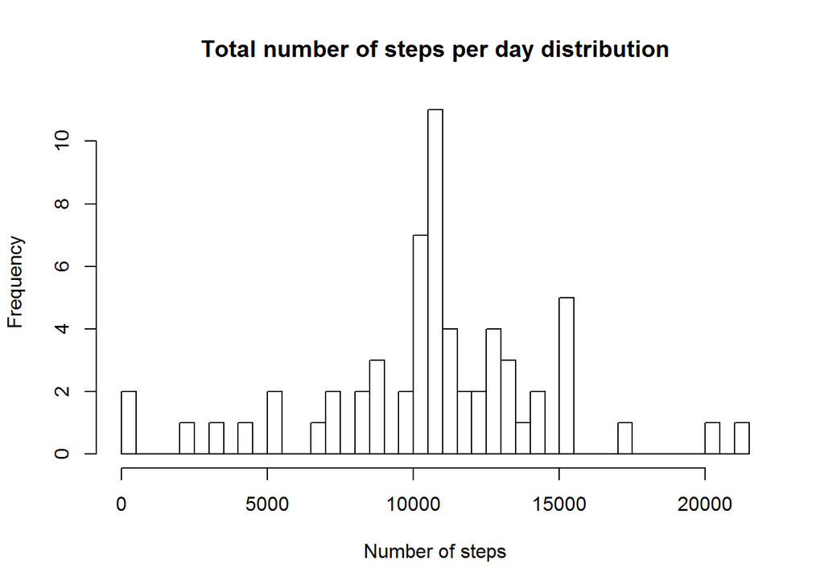

```r
options(scipen =1)
 c <-aggregate(steps ~ date, activity.i, sum)
 n <- dim(c)[1]
 hist( c$steps, xlab= "Number of steps", main="Total number of steps per day distribution",breaks=n)
```

```r
 step.mean.i <- mean(c$steps)
 step.median.i <-median(c$steps)
 step.mean.diff <- step.mean.i - step.mean
 step.median.diff <- step.median.i - step.median
 total.steps.diff <- total.activity.steps.i - total.activity.steps
```

The followings are the difference between imputed value for missing data and the original dataset.

Difference in the Total number of steps : 86129.51

Difference in the mean of the steps : 0

Difference in the median of the steps: 1.19

## Are there differences in activity patterns between weekdays and weekends?

There is a higher peak earlier on weekdays, and more overall activity on weekends as noted from the plot comparison between weekdays and weekends.

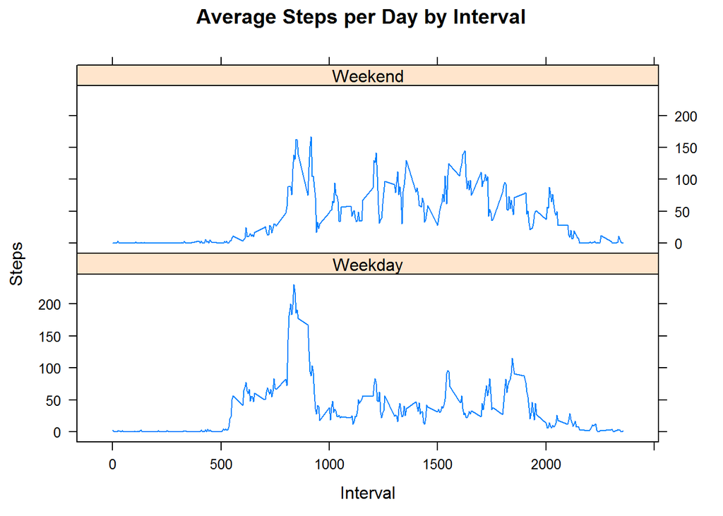

```r
weekdays <- c("Monday", "Tuesday", "Wednesday", "Thursday",
              "Friday")
activity.i$dow = as.factor(ifelse(is.element(weekdays(as.Date(activity.i$date)),weekdays), "Weekday", "Weekend"))

i.with.dow <- aggregate(steps ~ interval + dow, activity.i, mean)

library(lattice)

xyplot(i.with.dow$steps ~ i.with.dow$interval|i.with.dow$dow, main="Average Steps per Day by Interval",xlab="Interval",ylab="Steps", layout=c(1,2),type="l")
```